# < R : GGPLOT2을 이용한 기초 시각화 >

범례를 지우는 방법도 있다.

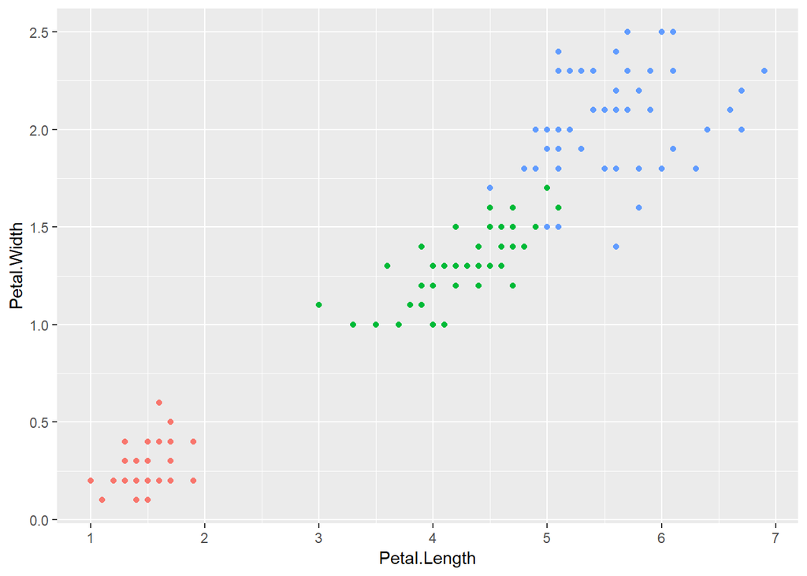

```r
ggplot(data = iris) +
  geom_point(mapping = aes(x = Petal.Length, y = Petal.Width, color = Species)) +
  scale_x_continuous(breaks = c(1,2,3,4,5,6,7)) +
  theme(legend.position = "none")
```

legend.position = “none” 대신 top/bottom/left/right를 입력하면 범례의 위치가 바뀌게 된다.

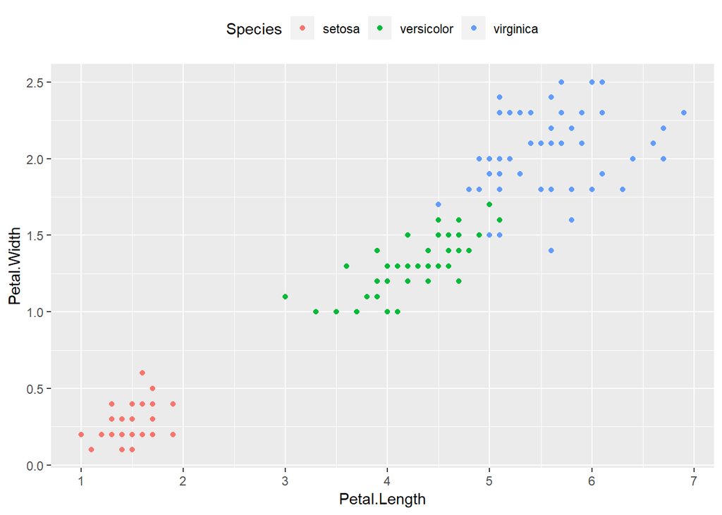

```r
iris_1 +
  theme(legend.position = "top")
```

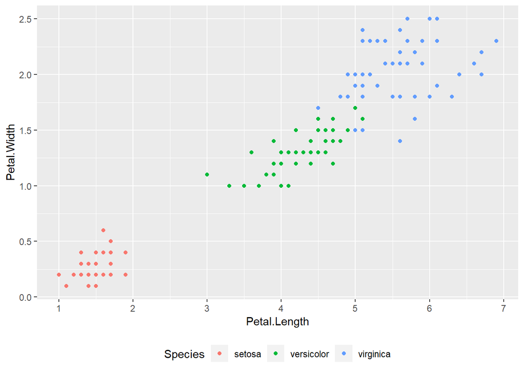

```r
iris_1 +
  theme(legend.position = "bottom")
```

범례의 위치를 그래프 외부가 아닌 내부로 옮기는 방법도 있다.

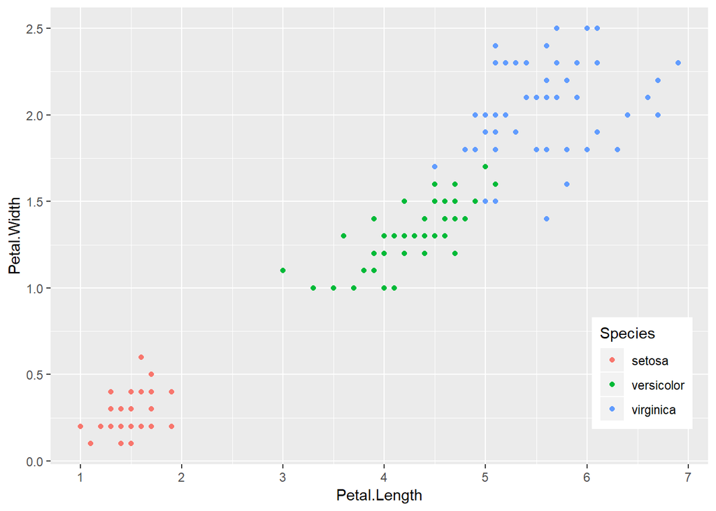

```r
iris_1 +
  theme(legend.position = c(0.9,0.2))
```

내부로 옮길때는 x,y축의 좌표점을 잘 입력해야된다. 기준은 범례의 정가운데를 좌표의 기준으로 잡는다. 그래프의 크기를 1x1로 봤을때, x와 y의 범위는 0<= x/y =< 1이 된다.

ex) 범례를 그래프의 중앙에 놓을때 legend.position = c(0.5,0.5)를 하면된다.

범례의 위치는 x/y를 바꿔주면서 수정하면서 원하는 위치로 옮겨질때까지 하면 된다.

#### 범례의 제목 수정

위에서는 범례의 제목 옵션을 바꾸는 것을 했지만 제목을 수정하는 방법에 대해서는 하지 않았다.

먼저, 범례의 제목만을 지우는 방법이다.

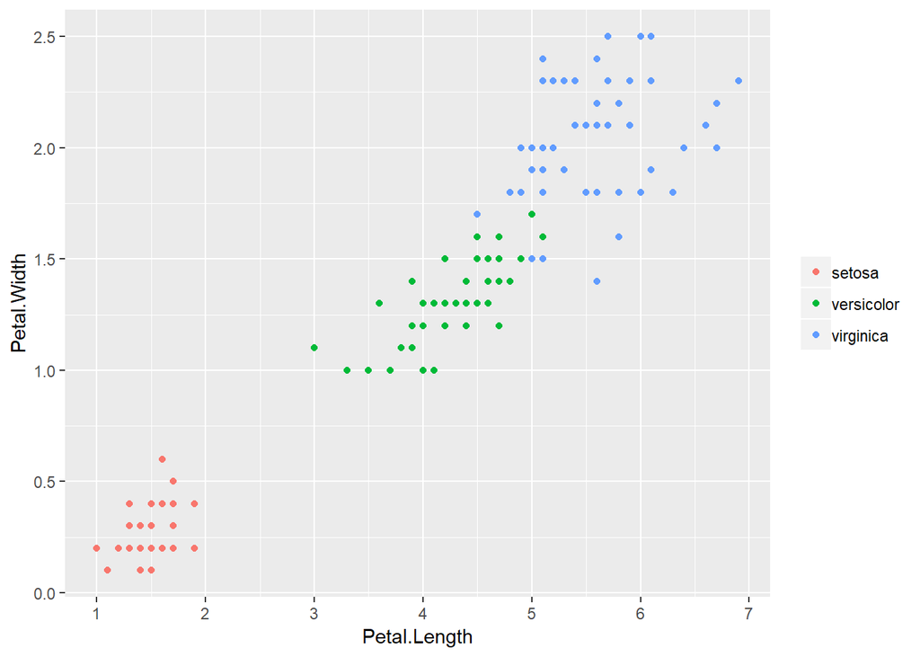

```r
iris_1 +
  theme(legend.title = element_blank())
```

위처럼 범례의 아이콘만 나오고 제목은 나오지를 않는다.

다음은 범례의 제목을 수정하는 방법이다.

범주가 연속형인지 이산형인지에 따라 사용하는 코드가 달라진다.

- scale_color_continuous(name ="") : 연속형 범주일 시 사용
- scale_color_discrete(name ="") : 이산형 범주일시 사용

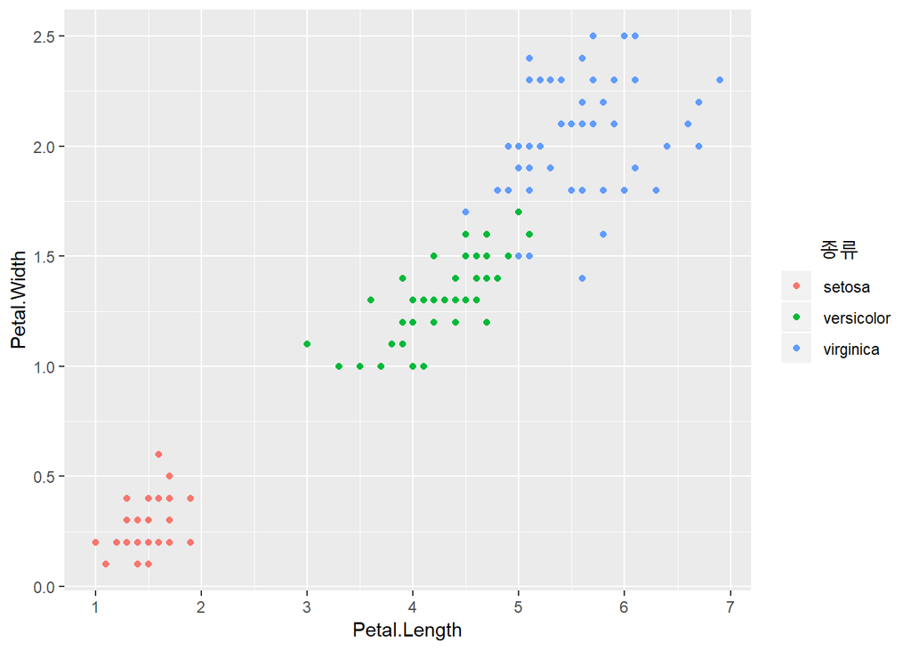

```r
iris_1 +
  scale_color_discrete(name = " 종류") +
  theme(legend.title = element_text(hjust = 0.5, size = 13))
```

범례의 제목에서 줄바꾸기를 원할때는 \n을 하면 된다.

……………………………………………………………………………………………………………………………………………………………………………

#### 4. 연습문제

imf 데이터를 이용해서 다음의 그래프를 작성하라.

(그래프 제목 크기 = 15, 범례 테두리 크기 2, 모든 제목은 중앙에 정렬)

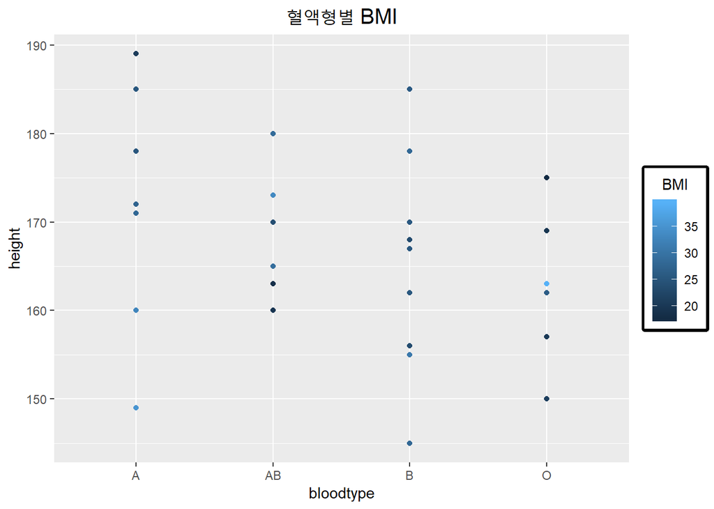

……………………………………………………………………………………………………………………………………………………………………………

### 5. 그래프 외 도형 그리기

그래프 안에 또다른 선/도형/점 등을 추가로 그리는 방법을 알아보자.

annotate() 함수를 이용해서 그래프 안에 선/도형/점 등을 그릴 수 있다.

- annotate(“text”, x = , y = , label = "", …) : 글자를 추가로 그린다.
- annotate(“rect”, xmin = , xmax = , ymin = , ymax = , alpha = , fill = "",…): 도형을 그린다.
- annotate(“segment”, x = , xend = , y = , yend = , colour = "", size ,= …)

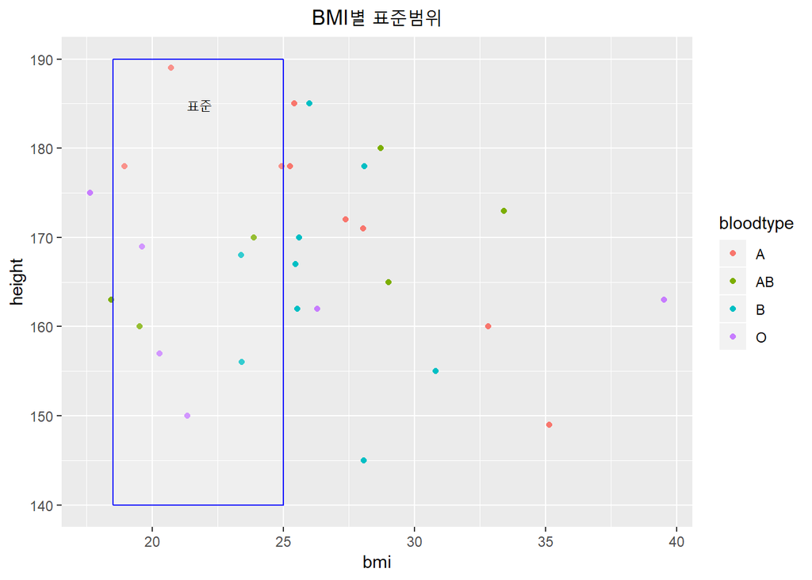

```r
imf$height <- as.numeric(as.character(imf$height))
imf$weight <- as.numeric(as.character(imf$weight))
imf$bmi <- imf$weight / ((imf$height/100)*(imf$height/100))

ggplot(imf) +
  geom_point(aes(x = bmi, y = height, color = bloodtype)) +
  annotate("rect", xmin = 18.5, xmax = 25, ymin = 140, ymax = 190, fill = "white", alpha = 0.2, color = "blue") +
  annotate("text", x = 21.8, y = 185, label ="표준") +
  ggtitle("BMI별 표준범위") +
  theme(plot.title = element_text(hjust = 0.5, size = 13))
```

……………………………………………………………………………………………………………………………………………………………………………

#### 6. 색깔 바꾸기

color를 더욱 자세히 바꿀 수 있다. ggplot2에서 제공하는 색상이 따로 있다.

scale_color_brewer()함수를 이용해서 색깔을 바꿀 수 있는데 색상에 대한 정보는 http://www.cookbook-r.com/Graphs/Colors_(ggplot2)/#a-colorblind-friendly-palette 로 들어가서 원하는 색상을 찾도록 하자.

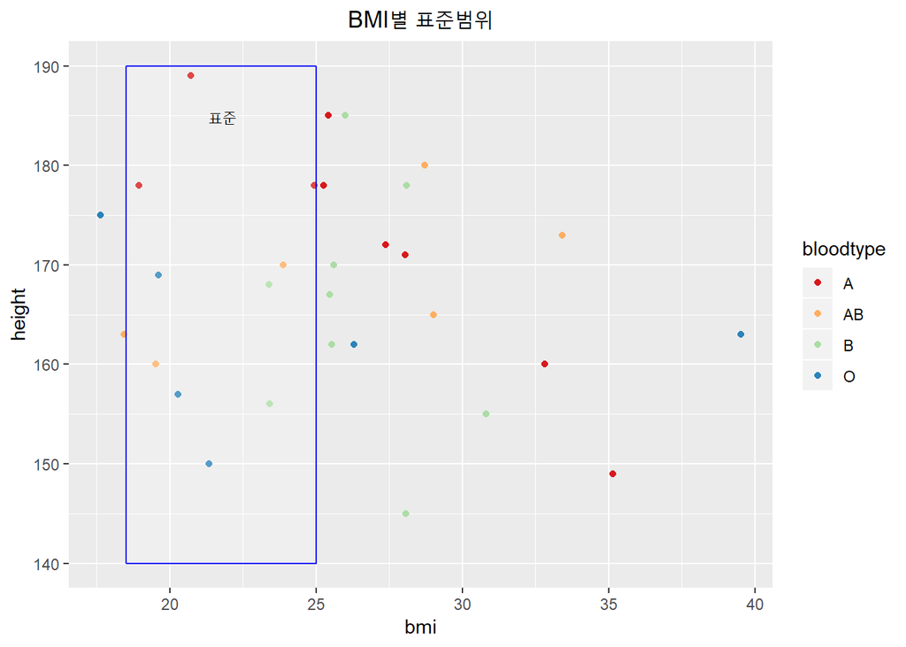

```r
ggplot(imf) +
  geom_point(aes(x = bmi, y = height, color = bloodtype)) +
  annotate("rect", xmin = 18.5, xmax = 25, ymin = 140, ymax = 190, fill = "white", alpha = 0.2, color = "blue") +
  annotate("text", x = 21.8, y = 185, label ="표준") +
  ggtitle("BMI별 표준범위") +
  theme(plot.title = element_text(hjust = 0.5, size = 13)) +
  scale_color_brewer(palette = "Spectral")
```

위의 그래프와 비교해보면, 색깔이 바뀐걸 알 수 있다. 사이트에 들어가서 찾은 색상 코드를 위처럼 작성하면 된다.

위처럼 말고 색상을 각각 하나씩 지정하고 싶으면 다음과 같이 하면 된다.

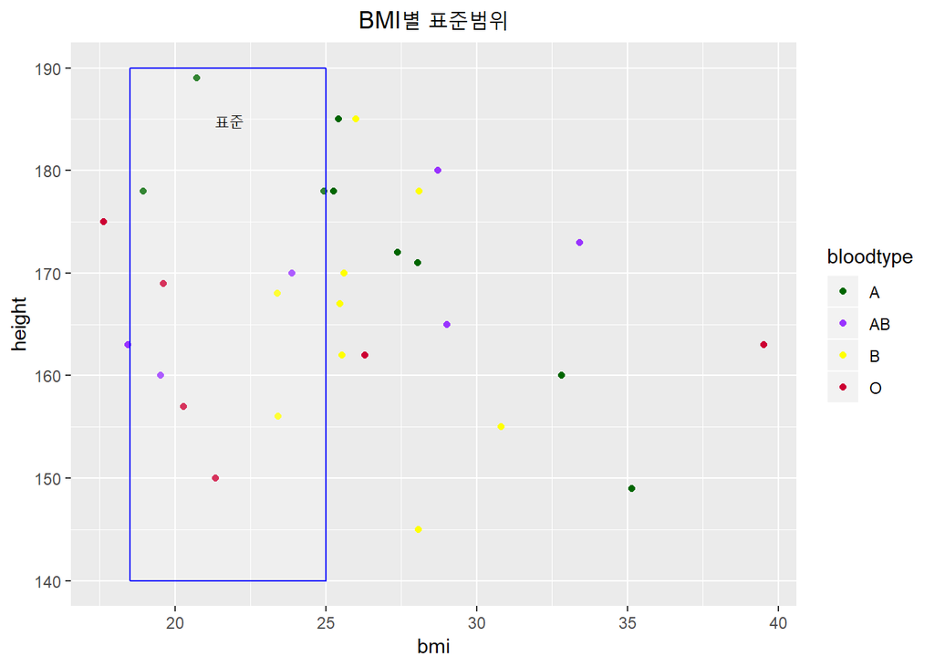

```r
ggplot(imf) +
  geom_point(aes(x = bmi, y = height, color = bloodtype)) +
  annotate("rect", xmin = 18.5, xmax = 25, ymin = 140, ymax = 190, fill = "white", alpha = 0.2, color = "blue") +
  annotate("text", x = 21.8, y = 185, label ="표준") +
  ggtitle("BMI별 표준범위") +
  theme(plot.title = element_text(hjust = 0.5, size = 13)) +
  scale_color_manual(values = c("#006600","#9933FF","#FFFF00","#CC0033"))
```

주의할 점은 “#”을 앞에다 붙이고 6자리 코드를 입력해야되며, 범례의 수와 입력한 색상의 수가 일치해야지 적용이 된다.

……………………………………………………………………………………………………………………………………………………………………………

#### 5. 연습문제

다음의 그래프를 만들어라.

- 데이터 : diamonds의 carat > 1인 값들
- 이상값 박스 x의 max/min(60/57) y의 max/min(93.5/97.5)
- 이상값 글자 위치 x,y = (62,92)
- 데이터 구분 값은 color로 할것

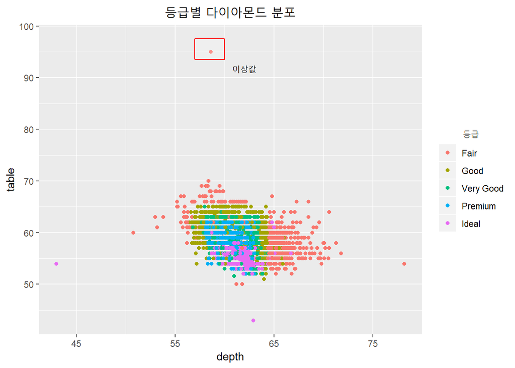

……………………………………………………………………………………………………………………………………………………………………………

#### 7. 테마(바탕효과) 바꾸기

항상 그래프가 그려진 것을 보면 회색 바탕에 흰색 줄무늬로 가로, 세로선이 그려져 있을 것이다. 이런 디폴트 값을 바꾸어 보자.

위에서 만들었던 iris 그래프 하나는 다음과 같아.

```r
ggplot(iris) +
  geom_point(aes(y = Petal.Width, x = Petal.Length, color = Species))
```

[output not shown]

facet_wrap()이라는 함수가 있는데 다음과 같은 표현을 나타내여 준다.

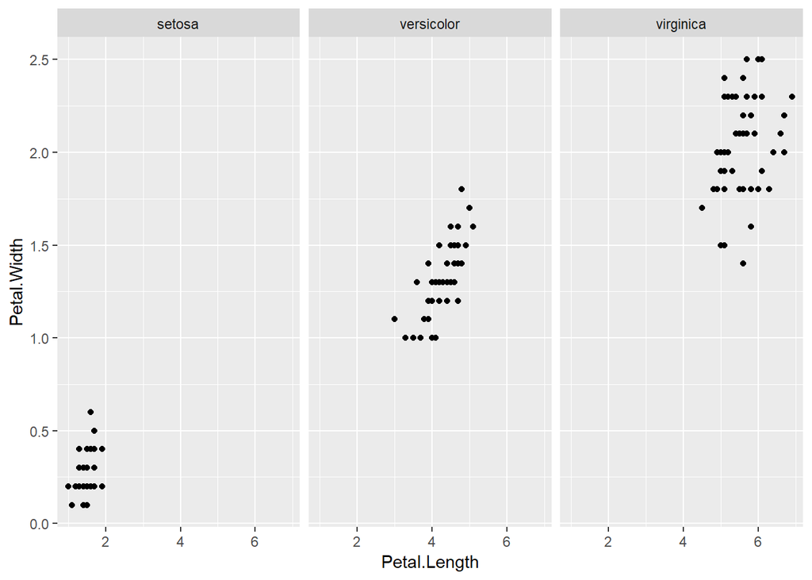

```r
ggplot(iris) +
  geom_point(aes(x = Petal.Length, y = Petal.Width)) +
  facet_wrap(~Species)
```

범례가 아닌 각각의 그래프로써 표현하게끔 해준다.

각각의 제목의 표현 옵션은 theme()으로 조정할 수 있다.

- strip.backgroud : 각각의 스크립(그래프)의 제목의 배경을 수정한다.
  - element_rect() : 스크립의 테투리를 수정한다.
- strip.text.x / strip.text.y : 각각의 스크립 안의 글자를 수정한다.
  - element_text() : 스크립 안의 글자를 수정한다.

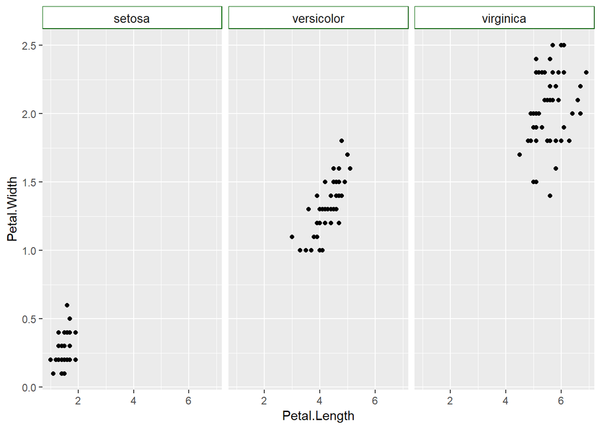

```r
ggplot(iris) +
  geom_point(aes(x = Petal.Length, y = Petal.Width)) +
  facet_wrap(~Species) +
  theme(strip.background = element_rect(fill = "white", color = "dark green")) +
  theme(strip.text.x = element_text(size = 10))
```

테마를 바꾸는 함수는 다음과 같다.

일단 gp5에 다음 코드를 저장하자.

```r
gp5 <- ggplot(iris, mapping = aes(x = Petal.Length, y = Petal.Width,color = Species)) +
  geom_point()
```

#### 테마(1) : theme_bw()

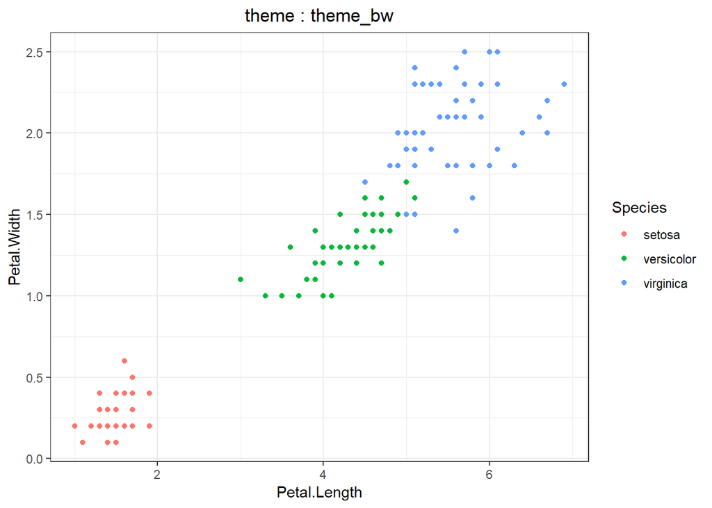

```r
gp5 +
  ggtitle("theme : theme_bw") +
  theme_bw() +
  theme(plot.title = element_text(hjust = 0.5))
```

#### 테마(2) : theme_void()

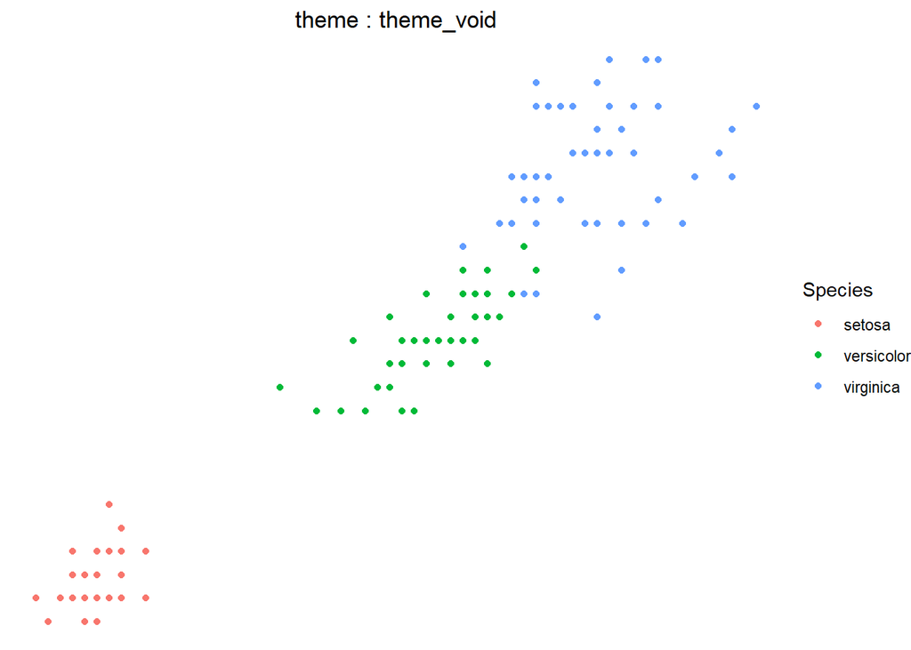

```r
gp5 +
  ggtitle("theme : theme_void") +
  theme_void() +
  theme(plot.title = element_text(hjust = 0.5))
```

#### 테마(3) : theme_classic()

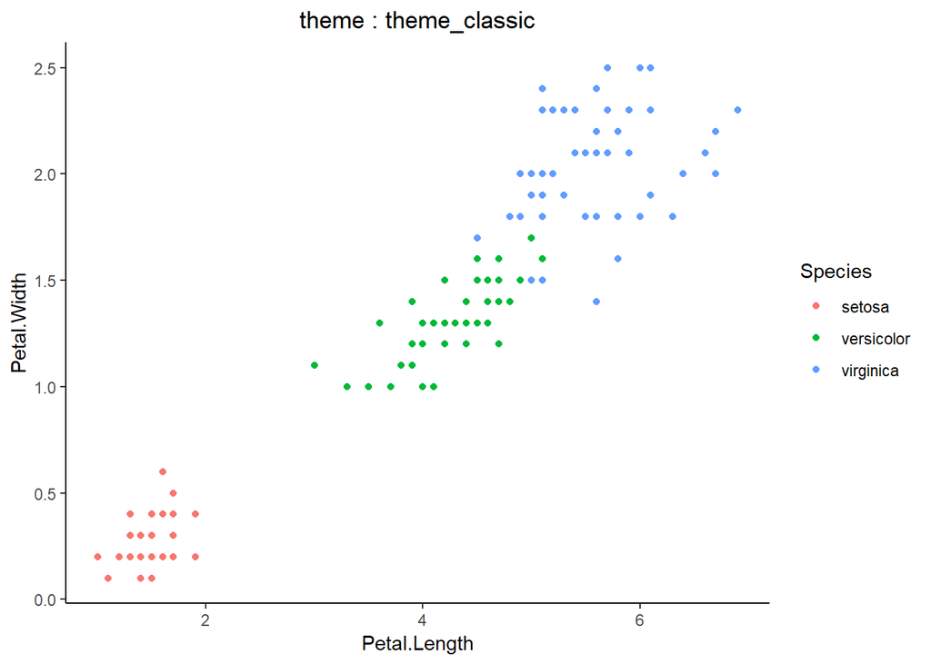

```r
gp5 +
  ggtitle("theme : theme_classic") +
  theme_classic() +
  theme(plot.title = element_text(hjust = 0.5))
```

#### 테마(4) : theme_light()

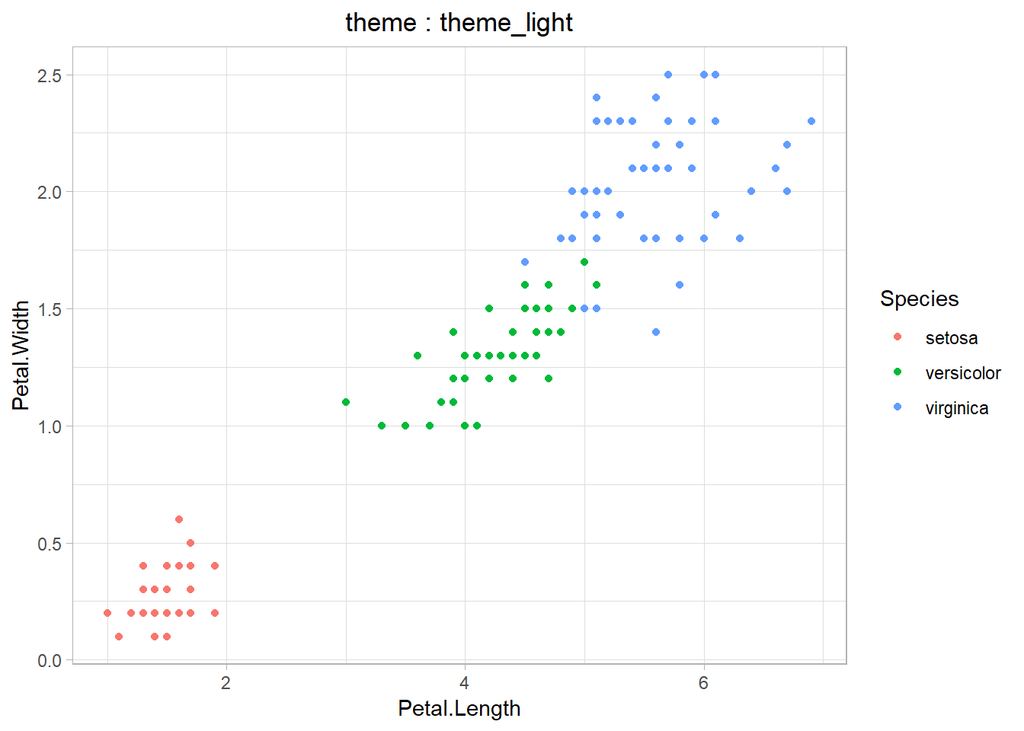

```r
gp5 +
  ggtitle("theme : theme_light") +
  theme_light() +
  theme(plot.title = element_text(hjust = 0.5))
```

#### 테마(5) : theme_minimal()

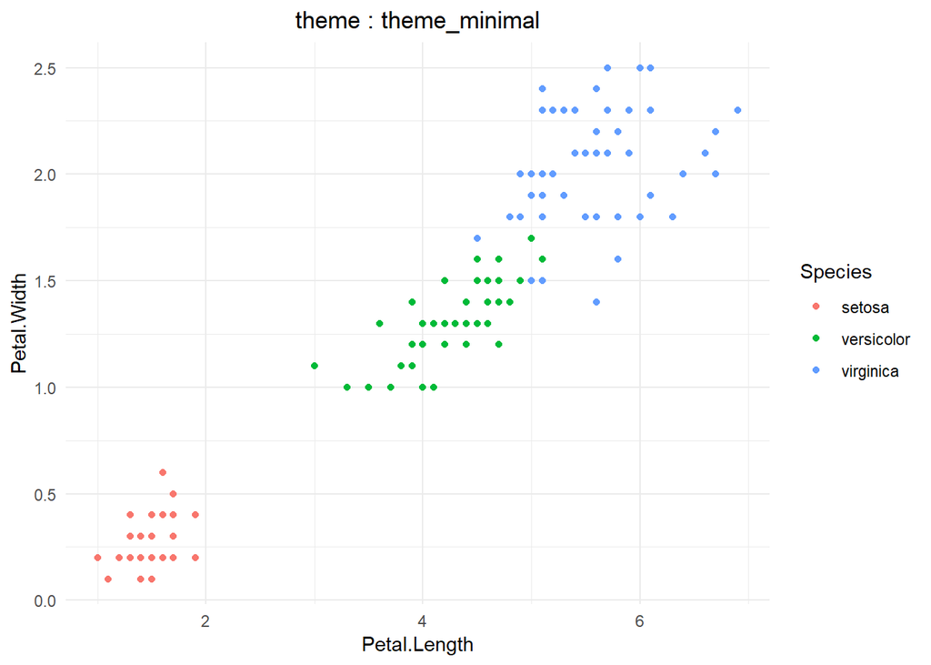

```r
gp5 +
  ggtitle("theme : theme_minimal") +
  theme_minimal() +
  theme(plot.title = element_text(hjust = 0.5))
```

#### 테마(6) : theme_dark()

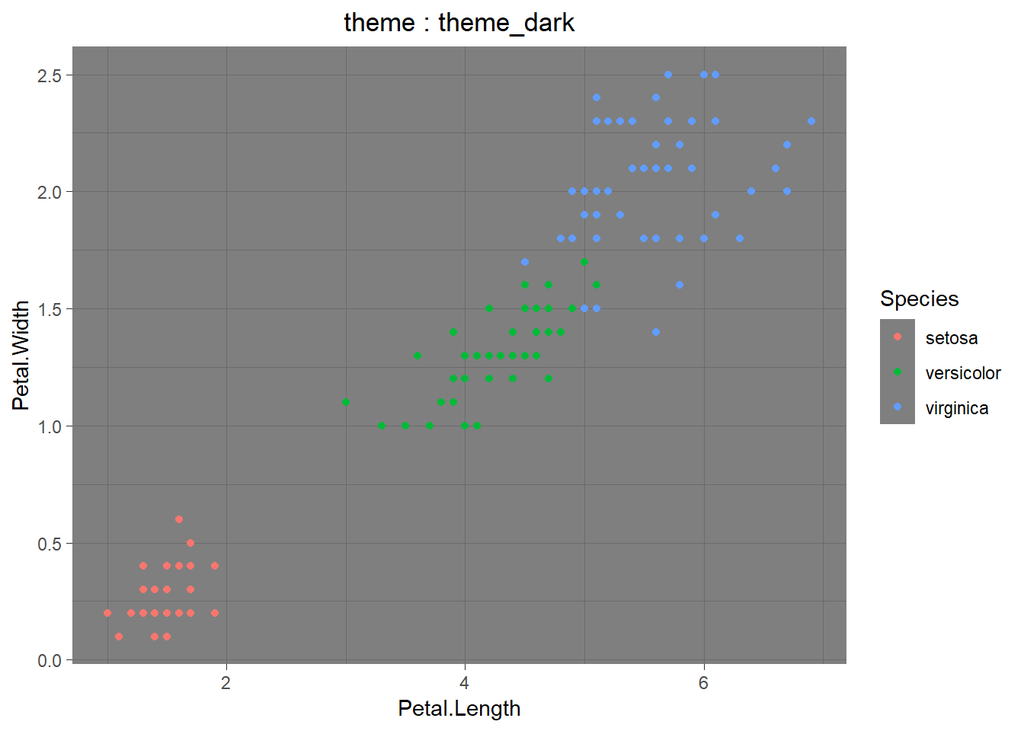

```r
gp5 +
  ggtitle("theme : theme_dark") +
  theme_dark() +
  theme(plot.title = element_text(hjust = 0.5))
```

#### 테마(7) : theme_gray()

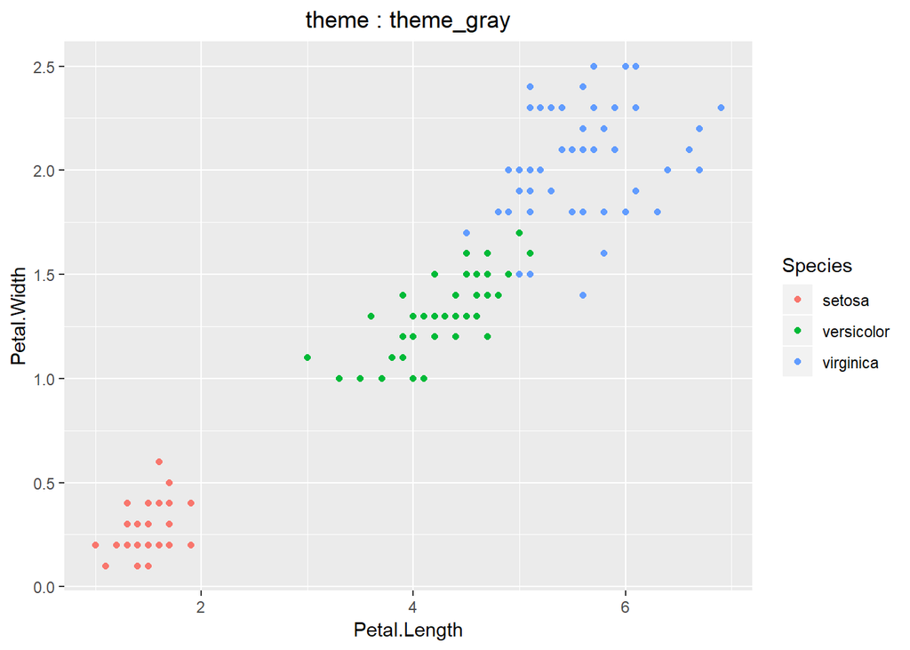

```r
gp5 +
  ggtitle("theme : theme_gray") +
  theme_gray() +
  theme(plot.title = element_text(hjust = 0.5))
```

위의 7개의 테마는 ggplot2패키지 안에 들어있는 기본적인 테마들이다.

외부에서 테마를 불러올 수 있다.

이를 위해서 패키지 ggthemes를 다운받아야 한다.

```r
library(ggthemes)
```

설치하고 library까지 마쳤으면 이제 테마를 적용해 보자.

혹시 윈도우에 없는 폰트라고 뜨면 위에서 썼던 “showtext”패키지를 라이브러리 하자.

#### 테마 : theme_economist()

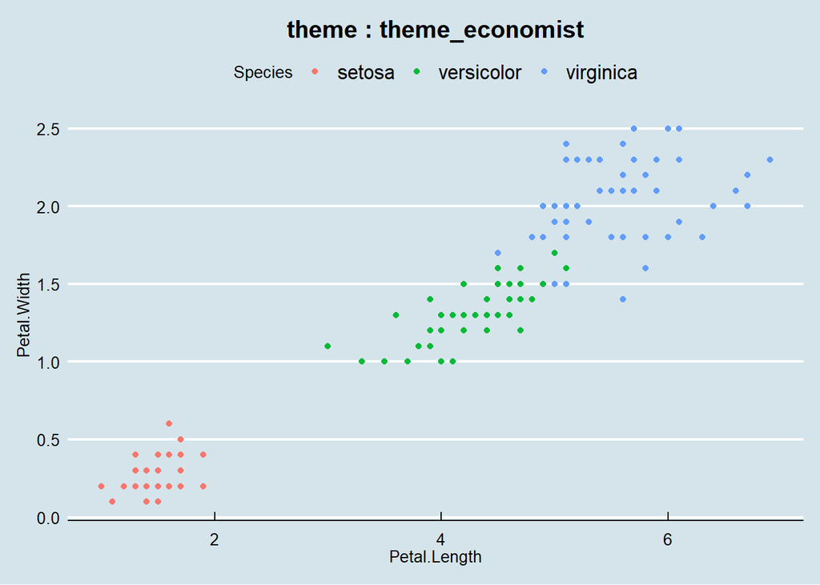

```r
gp5 +
  ggtitle("theme : theme_economist") +
  theme_economist() +
  theme(plot.title = element_text(hjust = 0.5))
```

#### 테마 : theme_hc()

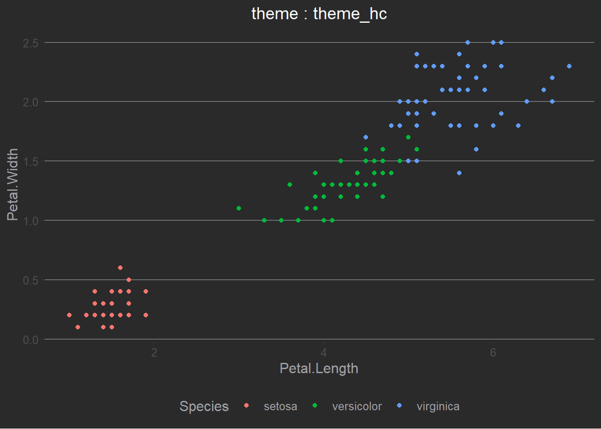

```r
gp5 +
  ggtitle("theme : theme_hc") +
  theme_hc(bgcolor = "darkunica") +
  theme(plot.title = element_text(hjust = 0.5))
```

theme_hc의 경우 bgcolor의 종류눈 : default 값 / darkunica 밖에 없다.

#### 테마 : theme_gdocs()

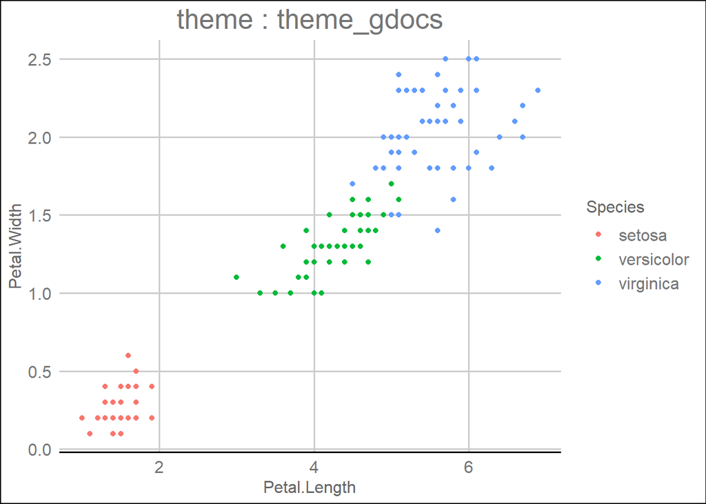

```r
gp5 +
  ggtitle("theme : theme_gdocs") +
  theme_gdocs() +
  theme(plot.title = element_text(hjust = 0.5))
```

위의 3개의 테마 말고도 더 많은 테마가 ggthemes안에 포함되어있다.

이에 대한 것은 https://www.rdocumentation.org/packages/ggthemes/versions/3.5.0 혹은 https://ggplot2.tidyverse.org/reference/ggtheme.html#arguments 들어가서 직접 이용해보도록 하자.